# PA1_template.Rmd

Rachel

2022-11-02

# Reproducible Research Course Project #1

Below is my report to complete Coursera’s Reproducible Research Course Project #1.

## Setup

```r
# Set seed
set.seed(215)
```

## Loading and preprocessing the data

Show any code that is needed to:

1. Load the data (i.e. read.csv())

```r
# Loading and preprocessing the data

filename <- "project1.zip"

# Checking if directory already exists.
if (!file.exists(filename)){
        fileURL <- "https://d396qusza40orc.cloudfront.net/repdata%2Fdata%2Factivity.zip"
        download.file(fileURL, filename, method="curl")
}

# Confirm zipped file is there
dir()
```

```
##  [1] "activity.csv"
##  [2] "Course_Project_1.R"
##  [3] "PA1_template_files"
##  [4] "PA1_template.html"
##  [5] "PA1_template.md"
##  [6] "PA1_template.Rmd"
##  [7] "project1.zip"
##  [8] "RepData_PeerAssessment1"
##  [9] "reportwriting.pdf"
## [10] "reproducible_research.Rproj"
## [11] "Structure of a Data Analysis Part 2.R"
```

```r
# Checking if folder exists
if (!file.exists("activity.csv")) {
        unzip(filename)
}

# Read in CSV and save file to object "data" and inspect it
data <- read.csv(file = "activity.csv", header = TRUE)
head(data)
```

```
##   steps       date interval
## 1    NA 2012-10-01        0
## 2    NA 2012-10-01        5
## 3    NA 2012-10-01       10
## 4    NA 2012-10-01       15
## 5    NA 2012-10-01       20
## 6    NA 2012-10-01       25
```

```r
str(data)
```

```
## 'data.frame':    17568 obs. of  3 variables:
##  $ steps   : int  NA NA NA NA NA NA NA NA NA NA ...
##  $ date    : chr  "2012-10-01" "2012-10-01" "2012-10-01" "2012-10-01" ...
##  $ interval: int  0 5 10 15 20 25 30 35 40 45 ...
```

```r
summary(data)
```

```
##      steps            date              interval
##  Min.   :  0.00   Length:17568       Min.   :   0.0
##  1st Qu.:  0.00   Class :character   1st Qu.: 588.8
##  Median :  0.00   Mode  :character   Median :1177.5
##  Mean   : 37.38                      Mean   :1177.5
##  3rd Qu.: 12.00                      3rd Qu.:1766.2
##  Max.   :806.00                      Max.   :2355.0
##  NA's   :2304
```

```r
# Data contain lots of NAs
# Leave NAs for now

## Confirm there are 17,568 observations
nrow(data) == 17568
```

```
## [1] TRUE
```

2. Process/transform the data (if necessary) into a format suitable for your analysis

```r
# Convert dates

library("lubridate")
data$date <- ymd(data$date)
str(data)
```

```
## 'data.frame':    17568 obs. of  3 variables:
##  $ steps   : int  NA NA NA NA NA NA NA NA NA NA ...
##  $ date    : Date, format: "2012-10-01" "2012-10-01" ...
##  $ interval: int  0 5 10 15 20 25 30 35 40 45 ...
```

## What is mean total number of steps taken per day?

1. Make a histogram of the total number of steps taken each day

```r
# Determine the total # of steps taken each day.

library("dplyr")
```

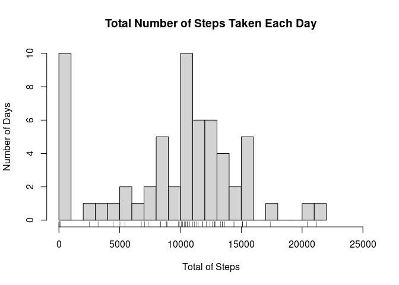

```r
sum_data <- data %>%
        group_by(date) %>%
        summarize(sum = sum(steps, na.rm = TRUE))

# Histogram of the total number of steps taken each day:

hist(sum_data$sum,
        breaks = 25,
        xlab = "Total of Steps",
        ylab = "Number of Days",
        main = "Total Number of Steps Taken Each Day",
        ylim = c(0,10),
        xlim = c(0,25000),
        )
rug(sum_data$sum)
```

2. Calculate and report the **mean** and **median** total number of steps taken per day

```r
# The mean for the total number of steps each day is:
mean(sum_data$sum)
```

```
## [1] 9354.23
```

```r
# The median for the total number of steps each day is:
median(sum_data$sum)
```

```
## [1] 10395
```

## What is the average daily activity pattern?

1. Make a time series plot (i.e. type = “l”) of the 5-minute interval (x-axis) and the average number of steps taken, averaged across all days (y-axis)

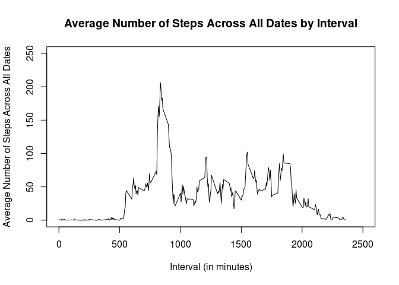

```r
# Calculate the average number of steps taken for each interval, averaged across all days

int_mean_data <- data %>%
        group_by(interval) %>%
        summarize(avg = mean(steps, na.rm = TRUE))

# Time series plot
with(int_mean_data,
     plot(interval, avg,
          type = "l",
          xlab = "Interval (in minutes)",
          ylab = "Average Number of Steps Across All Dates",
          main = "Average Number of Steps Across All Dates by Interval",
          ylim = c(0,250),
          xlim = c(0,2500),
     )
)
```

2. Which 5-minute interval, on average across all the days in the dataset, contains the maximum number of steps?

```r
#The 5-minute interval on average across all the days in the dataset that contains the maximum number of steps is:

int_mean_data[which.max(int_mean_data$avg),1]
```

```
## # A tibble: 1 × 1
##   interval
##      <int>
## 1      835
```